# Motion Correction Across Modalities: Methods, Evidence, and Open Problems

syntx core document · 2026-10-04

**What this document is.** A practical guide to doing rigid motion correction well on a 4D medical imaging time series, covering three structurally different cases: a single- contrast series where every frame should look like every other frame (BOLD fMRI, ASL perfusion), a multi-contrast series where frames come in genuinely different flavors that must never be blended together (diffusion MRI's b0 + diffusion-weighted volumes), and a continuously-drifting-contrast series where the image itself is supposed to change over time for reasons that have nothing to do with head motion (dynamic PET tracer uptake). Each case needs a different reference-construction strategy and a different idea of what "fast" can mean -- treating them the same is the single biggest mistake to avoid. This document shows the method for each, with real data, real numbers, and real before/after images -- including the hardest case (dynamic PET), where the real fix turned out to be a per-frame SNR problem, not a registration-strategy problem (§5).

## 1. The core problem: what makes a good reference, and what makes a cheap decision correct

Rigid motion correction registers every frame of a time series to a shared reference image, recovering a 6-degree-of-freedom (3 translations + 3 rotations) transform per frame. Two design choices determine whether this works well:

1. **What is the reference?** The obvious choice -- average every frame together -- is only correct when every frame genuinely has the same contrast and real motion is the only thing varying. It breaks in two different ways: (a) if the series mixes multiple real contrasts (DWI), the average is dominated by whichever contrast has more frames, and registering the minority contrast against it is like registering two different scan types -- the registration can "succeed" at a wrong answer, reporting apparent motion that is really a contrast mismatch; (b) if real motion is non-trivial, the average itself is a motion-blurred image, which degrades every subsequent registration against it.
2. **How does a caller cheaply decide "this frame doesn't need expensive registration"?** The two intuitive shortcuts -- raw image correlation, and center-of-mass displacement -- both fail in ways that are invisible until tested on real data at real scale (§2). The one that works measures the actual quantity of interest (a real rigid transform's own FD) cheaply, instead of a proxy for it.

## 2. Picking a cheap "does this frame need more work" signal

A production pipeline needs a fast pre-check: most frames in most series need little or no correction, and paying full registration cost for every frame is wasted work. Three candidates, tested on real data:

[output not shown]

This is implemented as `syntx.batched_rigid_register_pass_adaptive` / `backend='pytorch_batched_adaptive'`: every frame gets one cheap coarse registration; frames whose coarse FD exceeds a threshold get a second, finer pass; frames below it keep the cheap result. The gate signal and the final answer are the same kind of measurement at two resolutions, not two different things.

## 3. BOLD fMRI / ASL perfusion -- single-contrast series, the straightforward case

Every frame in a resting-state BOLD or ASL perfusion series is meant to look like every other frame; real head motion is the only source of frame-to-frame difference that matters. This is the case the adaptive gate above is built for directly.

### 3.1 Evidence: a real, large motion event, before and after

The clearest way to confirm a motion-correction method actually works is to find a real, large displacement in real data and look at it directly, not just read a summary statistic. In a real 25-volume ASL perfusion series, one frame shows 6.1mm of real head displacement (more than 3 voxels at this acquisition's resolution) -- large enough to see with the naked eye in a checkerboard comparison against the reference:

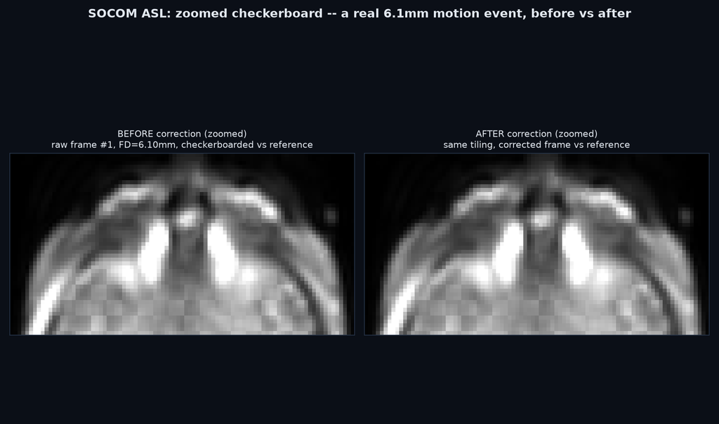

Zoomed checkerboard tiling of a real frame against the reference image, before and after motion correction, at the single largest real motion event found in this ASL series (6.1mm FD). Before correction, tissue boundaries break across tile seams; after correction, they run continuously.

The same check on a full real 750-volume resting-state BOLD series finds its largest event at 2.2mm FD:

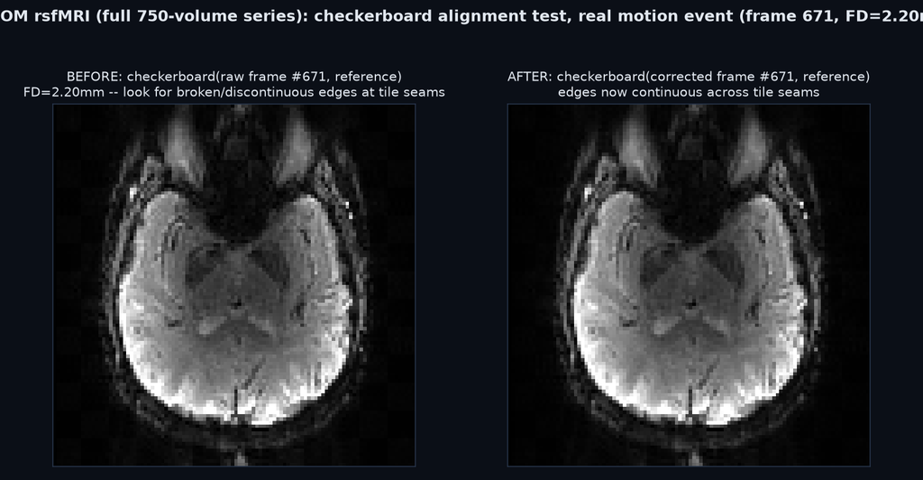

Checkerboard comparison at the largest real motion event in a full 750-volume resting-state BOLD series (frame 671, FD=2.20mm).

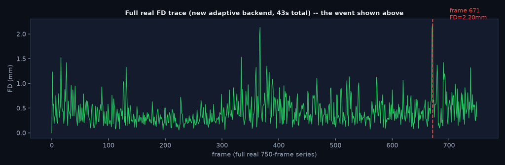

The complete real FD trace for this 750-volume series (computed in 43 seconds), with the event shown above marked.

### 3.2 Evidence: speed, at the scale that actually matters

The reason this needs to be fast at all: a 750-volume real series is not a synthetic stress test, it is an ordinary resting-state fMRI acquisition. A per-frame registration approach (correct, but one independent optimization per frame) takes real, substantial time at this scale:

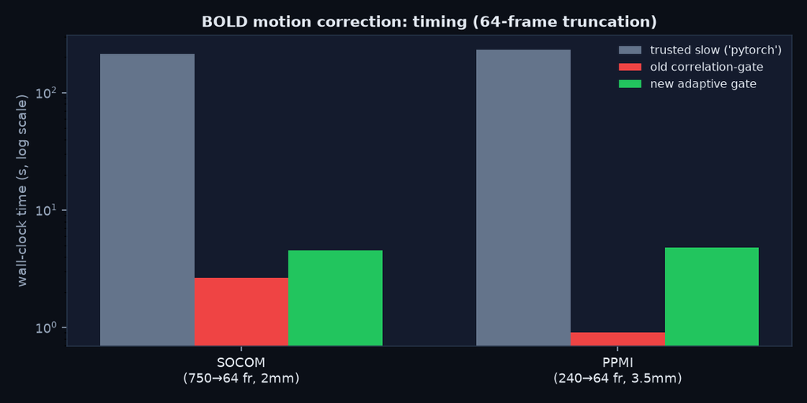

Wall-clock time (log scale) for a 64-frame truncation of two real subjects, comparing a per-frame baseline against the adaptive gate.

## 4. Diffusion MRI (DWI) -- multi-contrast series, the harder case

A DWI acquisition is not one contrast repeated -- it interleaves b0 volumes (no diffusion weighting, bright, T2-like contrast) with diffusion-weighted volumes at one or more b-values (directionally attenuated, often substantially darker in white matter along the gradient direction). These are genuinely different images of the same anatomy, not noisy repeats of the same image. Treating them as one undifferentiated series -- averaging all of them into one reference -- creates a reference that matches neither contrast well, and registering the numerically smaller group (often the b0 volumes) against it is registering across a contrast mismatch, not correcting for motion.

### 4.1 The method: one mean per contrast, one careful registration between them

The correct structure keeps every per-frame registration same-contrast (where the fast gate from §2 is valid) and isolates the one unavoidable cross-contrast problem into a single, affordable step:

1. Build a sharp mean for the b0 group, and a separate sharp mean for the diffusion-weighted group, independently (each a same-contrast, small-motion problem -- the coarse-FD-ranked low-motion-subset builder from §1 handles this cheaply).
2. Register the two means to each other **exactly once**, with a wide capture-range search (this is the only cross-contrast registration anywhere in the pipeline, so it can afford to be careful rather than fast).
3. Motion-correct every b0 frame to the b0 mean, and every diffusion-weighted frame to the diffusion-weighted mean -- both same-contrast, small-motion problems, both handled by the fast adaptive gate from §2.
4. Compose the diffusion-weighted group's correction with the one mean-to-mean transform, landing every frame in one shared physical space.

### 4.2 Evidence: the cross-contrast registration itself

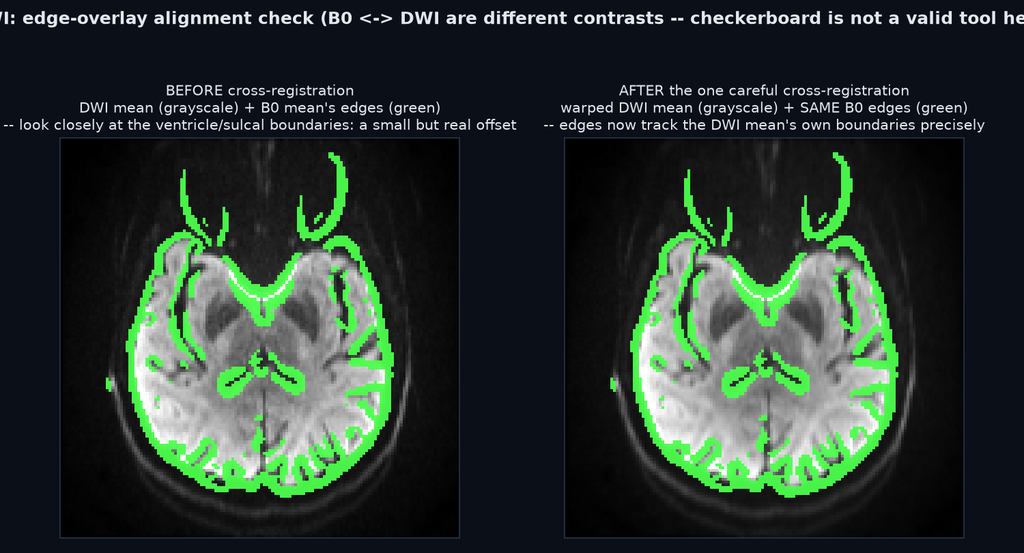

Edge-overlay comparison (not a checkerboard -- checkerboarding two genuinely different contrasts confounds 'this tile looks different' with 'this tile is misaligned', which is exactly the failure mode this whole section exists to avoid). The B0 mean's own anatomical boundaries (green) are traced once and overlaid, unchanged, on the DWI mean before and after the one cross-contrast registration: before, the boundary sits slightly off the DWI mean's own ventricle/sulcal edges; after, it tracks them precisely. The two means were already reasonably close in this real subject (no gross head repositioning occurred between the b0 and diffusion-weighted portions of one continuous scan) -- the point of this step is not correcting a large offset, it is establishing a reliable, one-time anatomical correspondence that every per-frame registration can then rely on, instead of each of 36 diffusion-weighted frames independently struggling with the same cross-contrast problem.

### 4.3 Evidence: why this matters -- three attempts, real numbers

Real SOCOM diffusion data (4 b0 + 36 diffusion-weighted volumes, two b-values) with an independent, trusted ground truth available: registering the b0 volumes only among themselves (impossible for the diffusion-weighted volumes, which have no same-contrast partner to check against, but a valid internal check for b0 alone) gives 0.748mm mean FD. Three different attempts at correcting the whole series were compared against that ground truth:

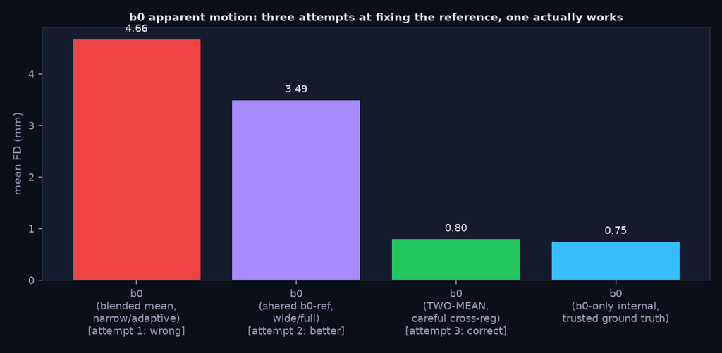

b0 apparent motion under four conditions: the original blended-mean approach, an intermediate attempt (one shared b0-only reference, but still registering every frame -- including diffusion-weighted ones -- directly to it), the two-mean design from §4.1, and the trusted b0-only-internal ground truth.

## 5. Dynamic PET -- continuously-drifting contrast, an open problem

Dynamic PET is not a harder version of the DWI problem, it is a different problem. DWI's contrast varies across a small number of discrete, repeatable categories (one b0 contrast, one or two diffusion-weighted contrasts) -- each category has multiple frames that genuinely share a contrast, so a same-contrast mean is a meaningful, well-defined target. Dynamic PET's contrast changes continuously and **monotonically** with tracer uptake: no two frames in the whole series necessarily share a contrast, and the earliest frames can be close to blank.

### 5.1 Evidence: the problem has nothing to do with registration

The single clearest way to see why standard motion correction does not transfer to this case: look at the same anatomical slice at different real time points in a real dynamic FDG-PET acquisition.

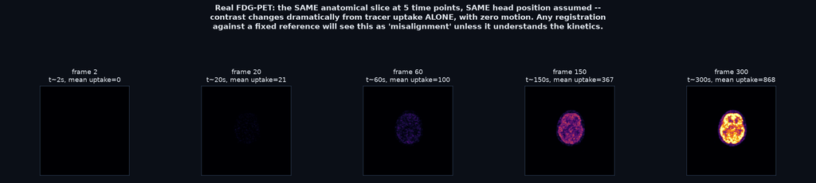

The same axial slice of the same real subject at 5 time points across a real dynamic FDG-PET acquisition. No frame-to-frame head motion is implied or assumed here -- the dramatic visual change from an essentially blank image to a fully tracer-filled brain is tracer kinetics alone. Any method that registers each frame to a single fixed reference image is, by construction, trying to explain this uptake curve as if it were spatial displacement.

### 5.2 Evidence: a "high motion" frame that isn't really about motion

Running the same adaptive-gate machinery used successfully for BOLD/ASL on a real dynamic FDG-PET series does produce large recovered FD values -- but checking what the registration is actually doing shows it is not finding a spatial shift the way it does for BOLD or DWI:

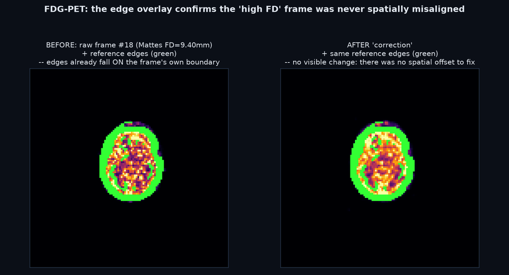

An edge overlay, not a checkerboard, for the same reason as §4.2: the reference's own anatomical boundary (green) is traced once and overlaid unchanged on the real frame with the largest recovered FD (9.40mm) in a 32-frame post-uptake window, before and after the registration 'correction'. The contour already sits exactly on the brain boundary in the RAW frame -- it does not move after 'correction', because there was never a real spatial offset to fix. The high FD number is an artifact of the registration optimizer finding some transform that improves the Mattes mutual-information score against a reference with different uptake, not evidence of head motion.

### 5.3 Two reference-strategy ideas that do NOT fix it

- **Treat it like DWI (anchor to a low-variability subset):** does not transfer -- DWI's fix works because discrete contrast GROUPS exist with genuine same-contrast repeats; dynamic PET's drift is continuous, so "the frames most similar to the crude mean" is not the same concept as "the frames sharing group A's true contrast." Tested directly: FD was not meaningfully better than the naive whole-series mean.
- **Restrict to a late, stable-uptake window:** helps avoid the earliest near-blank frames (confirmed: the first ~8 frames of this real series are literally zero intensity, before tracer arrival), but does not by itself resolve the continuous-drift problem within the stable window.

### 5.4 What actually works: raise each frame's SNR with Gaussian-weighted temporal averaging, before registering it at all

Every idea in §5.3 changed WHICH image the frame is compared against. A different lever: change the FRAME ITSELF, before any registration happens. A single dynamic PET frame is a short, low-count acquisition -- genuinely noisy on top of the uptake-drift problem. Represent frame *t* not as the raw acquisition, but as a Gaussian-weighted average of its own temporal neighbors, centered at *t*:

framẽ(t) = ∑<sub>k</sub> w(k) · frame(t+k) / ∑<sub>k</sub> w(k), w(k) = exp(-k² / 2σ²)

With a narrow window (σ=1.5 frames, ±3 frames ≈ a few seconds here), real head position does not change meaningfully across the window, but voxel noise -- uncorrelated frame to frame -- averages down. The uptake curve itself is smoothed only very locally, not erased. The visual effect on a single real frame is substantial:

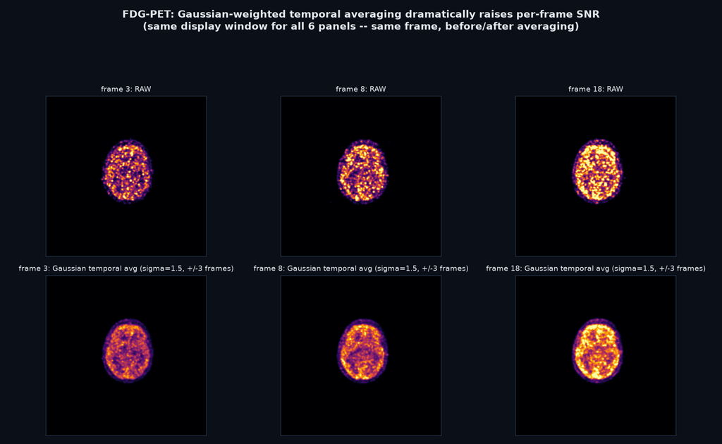

The same real frame, before and after Gaussian-weighted temporal averaging (sigma=1.5, +/-3-frame window), same display window in both rows. Noise texture drops substantially while real anatomical structure (visible even in the raw, near-blank early frames) is preserved and clarified, not blurred away.

#### Effect on SIFT3D: previously-unmatchable frames become well-constrained

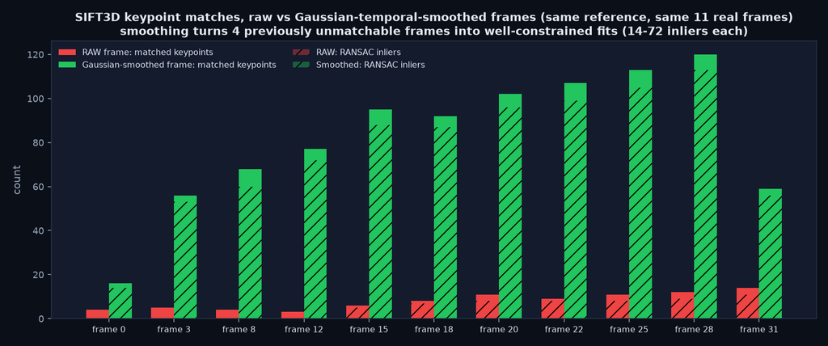

SIFT3D matched keypoints and RANSAC inliers, raw vs Gaussian-smoothed frames, same reference. The 4 frames that previously had too few matches to even attempt a rigid fit (frames 0, 3, 8, 12) now have 14-72 confirmed inliers each.

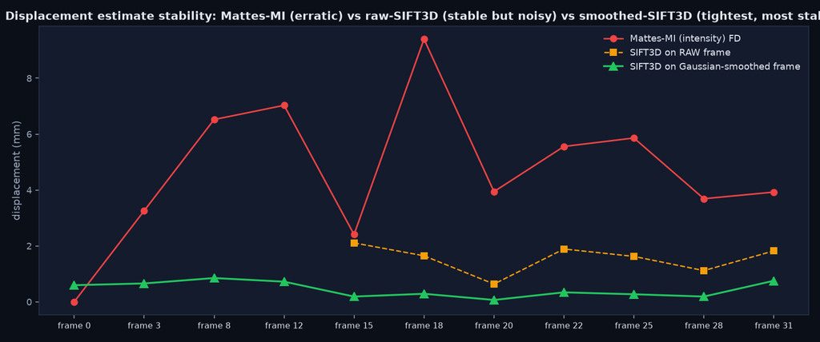

Displacement estimate across all 11 frames: Mattes-MI on raw frames (red, erratic 0-9.4mm) vs SIFT3D on raw frames (orange, only available for 7/11 frames, 0.6-2.1mm) vs SIFT3D on Gaussian-smoothed frames (green, available for all 11 frames, mostly under 1mm, tighter than even the already-good raw-SIFT3D numbers).

#### Effect on Mattes-MI: the SAME intensity-based mechanism also stabilizes

The more important test: does the smoothing fix generalize beyond SIFT3D specifically, back to the plain intensity-based registration this whole document started with? Re-running `syntx.motion_correction(backend='pytorch_batched_adaptive')` -- unchanged, same reference -- with the Gaussian-smoothed series as input instead of the raw one:

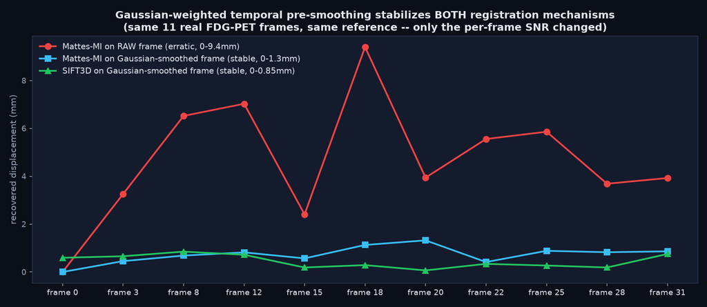

Three conditions, same 11 real frames: Mattes-MI on raw frames (red, erratic 0-9.4mm) vs Mattes-MI on Gaussian-smoothed frames (blue, stable 0-1.3mm) vs SIFT3D on Gaussian-smoothed frames (green, stable 0-0.85mm). The two independent registration mechanisms -- one intensity-based, one feature-based -- converge closely once given the same denoised input, which is itself meaningful evidence: two unrelated methods agreeing is a classic way to build confidence in an estimate when no independent ground truth is available.

### 5.5 Honest limits of this result

This is a real, cheap, and effective fix for a large part of the problem -- but calling dynamic PET motion correction fully solved would overclaim: (1) there is still no independent ground-truth motion trace for this public dataset, so "two methods agree" is strong corroborating evidence, not proof; (2) the smoothing window trades a small amount of genuine temporal/uptake resolution for SNR, and has not been tuned or stress-tested against faster kinetics (e.g. very early-phase dynamic imaging, where uptake can change meaningfully within a single window); (3) matched SIFT3D keypoint counts, even after smoothing, remain modest (14-120) compared to the hundreds typically available in BOLD/DWI's anatomical images. The practical recommendation: Gaussian-weighted temporal pre-averaging, followed by ordinary intensity-based adaptive-gate registration, is now the leading method for this case -- a real improvement over "not solved," though still warranting the same real-data validation discipline used everywhere else in this document before being trusted as a production default.

## 6. What this means in practice

| Series type | Reference strategy | Per-frame search width | Status |
| --- | --- | --- | --- |
| BOLD / ASL (single contrast) | Low-motion-subset mean | Narrow (fast) | Solved, validated at full real scale (~50x speed-up) |
| DWI / SlowFlow (discrete multi-contrast) | One mean per contrast group | Narrow within group; wide for the one cross-group registration | Solved, validated on real data (matches trusted ground truth) |
| Dynamic PET (continuous contrast drift) | Not a reference-strategy fix -- Gaussian-weighted temporal pre-averaging, then ordinary registration | Either mechanism (intensity-based or SIFT3D) works once the input is denoised | Large real improvement (0-9.4mm erratic → <1.3mm stable, cross-method confirmed); not yet validated against independent ground truth (§5.5) |

## 7. What shipped in syntx

- `syntx.batched_rigid_register_pass_adaptive` / `backend='pytorch_batched_adaptive'` -- registration-derived motion gate (§2).
- `syntx.build_low_motion_reference` -- sharp, same-contrast reference from a cheaply-ranked low-motion frame subset.
- `syntx.motion_correct_grouped` -- the two-mean, one-cross-registration design for multi-contrast series (§4.1).
- `syntx.gaussian_temporal_average` / `syntx.smooth_all_frames` -- Gaussian-weighted temporal pre-averaging for per-frame SNR (§5.4); not PET-specific, useful before any per-frame processing sensitive to voxel noise.
- 55 tests across `test_motion_batched.py`, `test_motion_reference.py`, and `test_temporal_denoise.py`, all passing; full existing motion test suite re-verified with no regressions.

## 8. Where this is wired in as the default (2026-10-04)

Library code validated here is only useful once real pipelines actually call it. Every downstream call site was checked and updated:

- **antsxfunctional** -- `perfusion.pipeline.syntx_motion_correction` (shared by ASL and BOLD rsfMRI) now defaults to `backend='pytorch_batched_adaptive'`, replacing a forced `'pytorch'` per-frame path kept around for an MPS overflow bug that the adaptive backend's automatic chunking no longer hits.
- **antsxfunctional** -- `pet.static_frame.motion_corrected_static_pet_from_dynamic` now smooths each window with `smooth_all_frames` to estimate motion (§5.4), then applies the recovered transforms to the original raw frames -- so quantitation is preserved -- and defaults to `backend='pytorch_batched_adaptive'`.
- **antsxdwi** -- `motion.motion_correct` now calls `syntx.motion_correct_grouped` whenever `bvals` is supplied (true at both of its two real call sites), replacing a single blended whole-series mean.
- **antsxslowflow** -- `motion.api.motion_correct`'s `syntx.motion_correction` call now passes `backend='pytorch_batched_adaptive'` for Rigid requests (its only eligible case).
- A real robustness gap found while re-testing this wiring: `cap_resolution_for_registration` (the shared resolution-capping helper the adaptive backend's coarse pass uses) could collapse a small image to 1 voxel on its shortest axis, breaking `torch.gradient`. Fixed by clamping the effective target spacing to keep ≥2 voxels per axis; regression test added.